# UNEB Results Analysis

In this notebook, we look at UNEB results for PLE, UCE and UACE. We provide some analysis to try and getter a better understanding of the results. The results are listed by school and show the performace in terms of how many students passed in a particular division.

This dataset is available from the [Data dot UG](http://catalog.data.ug/dataset/uneb-results-by-school) website. This website contains a number of datasets about Uganda that can be used for anlaysis.

We can then dive into the analysis

```python
ls
```

```
ple-results-by-school-2010-2015.csv  uce-results-by-school-2011-2016.csv
uace-results-2011-2015.csv
```

```python
import warnings
warnings.filterwarnings("ignore")
import pandas as pd
from matplotlib import pyplot as plt
import matplotlib as mpl
import seaborn as sns
%matplotlib inline
import numpy as np

ple = pd.read_csv('ple-results-by-school-2010-2015.csv')
uce = pd.read_csv('uce-results-by-school-2011-2016.csv')
uace = pd.read_csv('uace-results-2011-2015.csv')
```

```python
ple.head()
```

|  | YEAR | DISTRICT | SCHOOL | TOTAL CANDIDATES | TOTAL DIV 1 | % DIV 1 | TOTAL DIV 2 | % DIV 2 | TOTAL DIV 3 | % DIV 3 | ... | MALE TOTAL DIV2 | MALE % DIV2 | MALE TOTAL DIV3 | MALE % DIV3 | MALE TOTAL DIV4 | MALE % DIV4 | MALE TOTAL U | MALE % U | MALE TOTAL X | MALE % X |
| --- | --- | --- | --- | --- | --- | --- | --- | --- | --- | --- | --- | --- | --- | --- | --- | --- | --- | --- | --- | --- | --- |
| 0 | 2010 | KABAROLE | EXCEL PRIMARY SCHOOL,RWIMI | 23 | 23.0 | 100.0 | 0.0 | 0.0 | 0.0 | 0.0 | ... | NaN | 0.0 | NaN | 0.0 | NaN | 0.0 | NaN | 0.0 | NaN | 0.0 |
| 1 | 2010 | KALUNGU | SACRED HEART P/S, KYAMUSANSALA | 40 | 40.0 | 100.0 | 0.0 | 0.0 | 0.0 | 0.0 | ... | NaN | NaN | NaN | NaN | NaN | NaN | NaN | NaN | NaN | NaN |
| 2 | 2010 | KAMPALA | KING FAHAD ISLAMIC PRI. SCHOOL | 3 | 3.0 | 100.0 | 0.0 | 0.0 | 0.0 | 0.0 | ... | NaN | 0.0 | NaN | 0.0 | NaN | 0.0 | NaN | 0.0 | NaN | 0.0 |
| 3 | 2010 | KAMPALA | MAKINDYE JUNIOR SCHOOL | 1 | 1.0 | 100.0 | 0.0 | 0.0 | 0.0 | 0.0 | ... | NaN | 0.0 | NaN | 0.0 | NaN | 0.0 | NaN | 0.0 | NaN | 0.0 |
| 4 | 2010 | KAMPALA | WATERFORD P/S NAJJANANKUMBI | 19 | 19.0 | 100.0 | 0.0 | 0.0 | 0.0 | 0.0 | ... | NaN | 0.0 | NaN | 0.0 | NaN | 0.0 | NaN | 0.0 | NaN | 0.0 |

5 rows × 42 columns

```python
uce.head()
```

|  | YEAR | DISTRICT | SCHOOL | TOTAL CANDIDATES | TOTAL DIV 1 | % DIV 1 | TOTAL DIV 2 | % DIV 2 | TOTAL DIV 3 | % DIV 3 | ... | MALE TOTAL DIV3 | MALE % DIV3 | MALE TOTAL DIV4 | MALE % DIV4 | MALE TOTAL DIV7 | MALE % DIV7 | MALE TOTAL DIV9 | MALE % DIV9 | MALE TOTAL X | MALE % X |
| --- | --- | --- | --- | --- | --- | --- | --- | --- | --- | --- | --- | --- | --- | --- | --- | --- | --- | --- | --- | --- | --- |
| 0 | 2011 | WAKISO | GAYAZA HIGH SCHOOL | 176.0 | 175.0 | 99.4 | 1.0 | 0.6 | NaN | 0.0 | ... | NaN | 0.0 | NaN | 0.0 | NaN | 0.0 | NaN | 0.0 | NaN | 0.0 |
| 1 | 2011 | MUKONO | NAMILYANGO COLLEGE | 151.0 | 150.0 | 99.3 | NaN | 0.0 | NaN | 0.0 | ... | NaN | 0.0 | NaN | 0.0 | NaN | 0.0 | NaN | 0.0 | NaN | 0.7 |
| 2 | 2011 | MUKONO | MT.ST.MARY'S,NAMAGUNGA | 153.0 | 151.0 | 98.7 | 2.0 | 1.3 | NaN | 0.0 | ... | NaN | 0.0 | NaN | 0.0 | NaN | 0.0 | NaN | 0.0 | NaN | 0.0 |
| 3 | 2011 | WAKISO | UGANDA MARTYRS SS,NAMUGONGO | 222.0 | 216.0 | 97.3 | 6.0 | 2.7 | NaN | 0.0 | ... | NaN | 0.0 | NaN | 0.0 | NaN | 0.0 | NaN | 0.0 | NaN | 0.0 |
| 4 | 2011 | BUSHENYI MAIN | KITABI SEMINARY | 73.0 | 71.0 | 97.3 | 2.0 | 2.7 | NaN | 0.0 | ... | 2.0 | 0.0 | NaN | 0.0 | NaN | 0.0 | NaN | 0.0 | NaN | 0.0 |

5 rows × 48 columns

```python
uace.head()
```

|  | District_Name | SCHOOL | Gender | 2011 Total | %0-5 Points | %6-10 Points | %11-15 Points | %16-20 Points | %21-25 Points | 2012 Total | ... | 2014 Total | %0-5 Points.3 | %6-10 Points.3 | %11-15 Points.3 | %16-20 Points.3 | 2015 Total | %0-5 Points.4 | %6-10 Points.4 | %11-15 Points.4 | %16-20 Points.4 |
| --- | --- | --- | --- | --- | --- | --- | --- | --- | --- | --- | --- | --- | --- | --- | --- | --- | --- | --- | --- | --- | --- |
| 0 | AMUDAT | POKOT SECONDARY SCHOOL | FEMALE | NaN | 0.0 | 0.0 | 0.0 | 0.0 | 0.0 | 3.0 | ... | 2.0 | 50.0 | 0.0 | 50.0 | 0.0 | 1 | 0.0 | 0.0 | 100.0 | 0.0 |
| 1 | AMUDAT | NaN | MALE | NaN | 0.0 | 0.0 | 0.0 | 0.0 | 0.0 | 8.0 | ... | 9.0 | 55.6 | 44.4 | 0.0 | 0.0 | 4 | 25.0 | 50.0 | 25.0 | 0.0 |
| 2 | AMUDAT Total | NaN | NaN | NaN | 0.0 | 0.0 | 0.0 | 0.0 | 0.0 | 11.0 | ... | 11.0 | 54.5 | 36.4 | 9.1 | 0.0 |  | 20.0 | 40.0 | 40.0 | 0.0 |
| 3 | PADER | ARCHBP.FLYNN SECONDARY SCHOOL | FEMALE | NaN | 0.0 | 0.0 | 0.0 | 0.0 | 0.0 | NaN | ... | NaN | 0.0 | 0.0 | 0.0 | 0.0 | 14 | 21.4 | 42.9 | 35.7 | 0.0 |
| 4 | PADER | NaN | MALE | NaN | 0.0 | 0.0 | 0.0 | 0.0 | 0.0 | NaN | ... | NaN | 0.0 | 0.0 | 0.0 | 0.0 | 22 | 40.9 | 50.0 | 9.1 | 0.0 |

5 rows × 30 columns

To make the use of the different columns easier, I will change them to lower case and also remove any white space around them

```python
for dataset in [ple, uce, uace]:
    dataset.columns = dataset.columns.map(str.lower)
    dataset.columns = dataset.columns.map(str.strip)
```

```python
ple.columns
```

```
Index([u'year', u'district', u'school', u'total candidates', u'total div 1',
       u'% div 1', u'total div 2', u'% div 2', u'total div 3', u'% div 3',
       u'total div 4', u'% div 4', u'total u', u'% u', u'total x', u'% x',
       u'female candidates', u'female total div1', u'female % div1',
       u'female total div2', u'female % div2', u'female total div3',
       u'female % div3', u'female total div4', u'female % div4',
       u'female total u', u'female % u', u'female total x', u'female % x',
       u'male candidates', u'male total div1', u'male % div1',
       u'male total div2', u'male % div2', u'male total div3', u'male % div3',
       u'male total div4', u'male % div4', u'male total u', u'male % u',
       u'male total x', u'male % x'],
      dtype='object')
```

I decided to create a score that would aggregate the percentages of the different divisions, attaching different weights to each of them. The score ranges from 0 to 100

```python
def score(x):
    return x['% div 1'] + x['% div 2']*0.5 + x['% div 3']/float(3) +x['% div 4']*0.25 + x['% u']*0.1 + x['% x']*0
ple['score'] = ple.apply(score, axis=1)
```

Using this score we can then obtain the top performing schools per year.

```python
ple_by_year = ple.groupby('year')
```

```python
ple_year_ranks={}
for year, group in ple_by_year:
    ple_year_ranks[year]= group[['school', 'score']].sort_values(by='score',ascending=False).drop_duplicates()
```

```python
ple_year_ranks[2014].iloc[:20]
```

|  | school | score |
| --- | --- | --- |
| 56579 | PEARL JUNIOR SCHOOL | 100.0 |
| 56639 | IBANDA TOWN PRIMARY SCHOOL | 100.0 |
| 56663 | 43 NANKANDULO PRIMARY SCHOOL | 100.0 |
| 56672 | MBALE TOWER PRIMARY SCHOOL | 100.0 |
| 56671 | VICTORY LEARNING PRI. SCHOOL | 100.0 |
| 56670 | BRIGHT GRAMMAR PRIMARY SCHOOL | 100.0 |
| 56669 | GATEWAY PRIMARY SCHOOL | 100.0 |
| 56668 | STANDARD INTERGRATED PIS | 100.0 |
| 56667 | KITOORO HILL VIEW PRI. SCHOOL | 100.0 |
| 56666 | HORMISDALLEN MIXED DAY AND BDG | 100.0 |
| 56665 | 9 NANKANDULO PRIMARY SCHOOL | 100.0 |
| 56664 | 55 NANKANDULO PRIMARY SCHOOL | 100.0 |
| 56662 | 42 NANKANDULO PRIMARY SCHOOL | 100.0 |
| 56661 | 36 NANKANDULO PRIMARY SCHOOL | 100.0 |
| 56660 | 32 RUKUUBA PRIMARY SCHOOL | 100.0 |
| 56659 | 28 RUKUUBA PRIMARY SCHOOL | 100.0 |
| 56658 | 18 RUKUUBA PRIMARY SCHOOL | 100.0 |
| 56657 | 17 RUKUUBA PRIMARY SCHOOL | 100.0 |
| 56656 | 12 RUKUUBA PRIMARY SCHOOL | 100.0 |
| 56654 | IBANDA TOWN PRIMARY SCHOOL | 100.0 |

We notice some schools are repeated however with different integer values prepended to their names, seemingly making them unique. This is why they were not removed by the drop_duplicates function in the previous statement. We make a function called trim_name that takes off the integer prefix, so that we can then easily drop the duplicates.

```python
def trim_name(x):
    words = x.split()
    try:
        a=int(words[0])
        n= ' '.join(words[1:])
        return n.strip()
    except:
        return x.strip()

for year in ple_year_ranks:
    ple_year_ranks[year]['school']= ple_year_ranks[year]['school'].apply(trim_name)
    ple_year_ranks[year].drop_duplicates(inplace=True)
```

```python
ple_year_ranks[2014].iloc[:20]
```

|  | school | score |
| --- | --- | --- |
| 56579 | PEARL JUNIOR SCHOOL | 100.00 |
| 56639 | IBANDA TOWN PRIMARY SCHOOL | 100.00 |
| 56663 | NANKANDULO PRIMARY SCHOOL | 100.00 |
| 56672 | MBALE TOWER PRIMARY SCHOOL | 100.00 |
| 56671 | VICTORY LEARNING PRI. SCHOOL | 100.00 |
| 56670 | BRIGHT GRAMMAR PRIMARY SCHOOL | 100.00 |
| 56669 | GATEWAY PRIMARY SCHOOL | 100.00 |
| 56668 | STANDARD INTERGRATED PIS | 100.00 |
| 56667 | KITOORO HILL VIEW PRI. SCHOOL | 100.00 |
| 56666 | HORMISDALLEN MIXED DAY AND BDG | 100.00 |
| 56660 | RUKUUBA PRIMARY SCHOOL | 100.00 |
| 56582 | MARGHERITA PRIMARY SCHOOL | 100.00 |
| 56581 | KABALE PREPARATORY SCHOOL | 100.00 |
| 56580 | ST.CLELIA PRIMARY SCHOOL | 100.00 |
| 56673 | LEO'S JUNIOR PRIMARY SCHOOL | 99.70 |
| 56674 | NAMAGUNGA PRIMARY BOARDING SCH | 99.65 |
| 56675 | ST.KIZITO P.7 SCHOOL | 99.55 |
| 56676 | VILLA ROAD PRIMARY SCHOOL | 99.40 |
| 56677 | SIR APOLLO KAGGWA PIS NAKASERO | 99.35 |
| 56679 | WINSTON PRIMARY SCHOOL | 99.25 |

We now have the duplicates removed and this gives us a clearer picture of the school's performances. We can now see the best performig schools for each year.

```python
for year in ple_year_ranks:
    print 'The best schools in ' + str(year)
    print ple_year_ranks[year][:10].reset_index().drop('index', axis=1)
    print '\n'
```

```
The best schools in 2010
                           school  score
0      EXCEL PRIMARY SCHOOL,RWIMI  100.0
1  KING FAHAD ISLAMIC PRI. SCHOOL  100.0
2          MAKINDYE JUNIOR SCHOOL  100.0
3     WATERFORD P/S NAJJANANKUMBI  100.0
4       MARGHERITA PRIMARY SCHOOL  100.0
5            PARENTAL CARE SCHOOL  100.0
6       VILLA ROAD PRIMARY SCHOOL  100.0
7    KYENGERA PARENTS PRI. SCHOOL  100.0
8              ST.FRANCIS NANSANA  100.0
9  SACRED HEART P/S, KYAMUSANSALA  100.0


The best schools in 2011
```

[output cut: 67 more lines]

We can also look at the overall best performing schools over the course of the 6 years of the survey. First we shall use the trim_name method on the original list of schools

```python
ple['school']=ple['school'].apply(trim_name)
```

We can then drop the schools that are duplicated in a particular year

```python
ple.drop_duplicates(['school', 'year'], inplace=True)
```

We can then proceeed with our analysis. We get the average performance of each school over the entire study and then figure out which schools have performed best over this period.

```python
ple_schools = ple.groupby('school')
overall_schools= ple_schools['score'].mean()
```

```python
overall_schools.sort_values(ascending=False)[:20]
```

```
school
ST.CLELIA PRIMARY SCHOOL          100.000000
STANDARD INTERGRATED PIS          100.000000
VILLA ROAD PRIMARY SCHOOL          99.766667
VICTORY LEARNING PRI. SCHOOL       99.641667
ST.MARYS IMMACULATE VILLA P/S      99.580000
SIR APOLLO KAGGWA PIS NAKASERO     99.350000
K.Y DAY AND BOARDING P/S           99.340000
SIR APOLLO KAGGWA PIS MENGO        99.200000
MARGHERITA PRIMARY SCHOOL          99.150000
WINSTON PRIMARY SCHOOL             99.100000
ENTEBBE EDUCATION CENTRE PIS       98.800000
AUNTIE AGNES INFANT P/S,MITETE     98.750000
HAPPY YEARS SCHOOL                 98.610000
K.Y DAY AND BOARDING PIS           98.600000
HORMISDALLEN KIRINNYA P/S          98.570000
BISHOP ASILI MEM. NURSERY PIS      98.550000
EXCEL PRIMARY SCHOOL,RWIMI         98.500000
PEARL JUNIOR SCHOOL                98.475000
RISE & SHINE PRIMARY SCHOOL        98.300000
SIR APOLLO KAGGWA P/S MENGO        98.260000
Name: score, dtype: float64
```

We can see that the schools that feature here are mainly the schools we saw when we did a year by year performance analysis.

We can also look at the representation of the different districts among the top performing schools.

We can also look at this in terms of the school that are perenially among the top schools every year. For this we shall check to see which schools are among the top 100 schools each year from 2010 to 2015 and then order them by their score.

We already have the ple_year_ranks dictionary that ranks the schools in order of their score per year, so we shall use this and a set operation to obtain these schools.

```python
best_schools=[]
for year in ple_year_ranks:
    best_schools.append(set(ple_year_ranks[year][:100].school.tolist()))
perenial_best = list(set.intersection(*(best_schools)))
perenial_best
```

```
['MARGHERITA PRIMARY SCHOOL',
 'KABALE PREPARATORY SCHOOL',
 'UGANDA MARTYRS KATWE P SCHOOL',
 'NAMIRYANGO JUNIOR BOYS P/S',
 'VICTORY LEARNING PRI. SCHOOL',
 'VILLA ROAD PRIMARY SCHOOL',
 'PEARL JUNIOR SCHOOL',
 'EXCEL PRIMARY SCHOOL,RWIMI',
 'WINSTON PRIMARY SCHOOL',
 "LEO'S JUNIOR PRIMARY SCHOOL"]
```

Interestingly there are only 10 schools that are in the top 100 schools every year. It is important to note that the score we came up with relies on the percentages of students in each division attaching different weights to each. As a result, a school that has many students that really excel as well as most getting very good grades but all has some students scoring in the lower divisions may not be consistently be at the top even though it is considered to do well perenially.

This should explain why many of the schools that we know to be among the best do not show up in the list above. Also this kind of scoring using the percentages in each division means that a school can easily fall out of the top schools in a particular. In addition to that, PLE is relatively competitive as evidenced from the data. A very huge number of schools have many students in the top divisions.

After that explanation we can plot them on a map to see where these schools are located and the distribution of the perenially well performing schools.

```python
indexer =[]
ple2015 = ple[ple['year']==2015]
for school in perenial_best:
    i = ple2015[ple2015['school']== school][['school', 'district']].index.values.tolist()
    indexer = indexer + i

perennial_df = ple2015.ix[indexer][['school', 'district']]
perennial_df
```

|  | school | district |
| --- | --- | --- |
| 44966 | MARGHERITA PRIMARY SCHOOL | KASESE M/C |
| 45040 | KABALE PREPARATORY SCHOOL | KABALE M/C |
| 44972 | UGANDA MARTYRS KATWE P SCHOOL | MASAKA M/C |
| 45038 | NAMIRYANGO JUNIOR BOYS P/S | MUKONO M/C |
| 44988 | VICTORY LEARNING PRI. SCHOOL | MASAKA M/C |
| 44973 | VILLA ROAD PRIMARY SCHOOL | MASAKA M/C |
| 44957 | PEARL JUNIOR SCHOOL | BUSHENYI M/C |
| 45051 | EXCEL PRIMARY SCHOOL,RWIMI | KABAROLE |
| 44994 | WINSTON PRIMARY SCHOOL | KAMPALA |
| 44990 | LEO'S JUNIOR PRIMARY SCHOOL | MASAKA M/C |

```python
import geocoder
def add_coordinates(district):
    coords = geocoder.google(district.split()[0] + ', UGANDA').latlng
    return coords

perennial_df['coordinates'] = perennial_df['district'].apply(add_coordinates)
```

```python
perennial_df
```

|  | school | district | coordinates |
| --- | --- | --- | --- |
| 44966 | MARGHERITA PRIMARY SCHOOL | KASESE M/C | [0.1698986, 30.078078] |
| 45040 | KABALE PREPARATORY SCHOOL | KABALE M/C | [-1.241956, 29.9856157] |
| 44972 | UGANDA MARTYRS KATWE P SCHOOL | MASAKA M/C | [-0.3267383, 31.7537404] |
| 45038 | NAMIRYANGO JUNIOR BOYS P/S | MUKONO M/C | [0.3548655, 32.7520139] |
| 44988 | VICTORY LEARNING PRI. SCHOOL | MASAKA M/C | [-0.3267383, 31.7537404] |
| 44973 | VILLA ROAD PRIMARY SCHOOL | MASAKA M/C | [-0.3267383, 31.7537404] |
| 44957 | PEARL JUNIOR SCHOOL | BUSHENYI M/C | [-0.4870918, 30.2051096] |
| 45051 | EXCEL PRIMARY SCHOOL,RWIMI | KABAROLE | [0.5896682, 30.2548787] |
| 44994 | WINSTON PRIMARY SCHOOL | KAMPALA | [0.3475964, 32.5825197] |
| 44990 | LEO'S JUNIOR PRIMARY SCHOOL | MASAKA M/C | [-0.3267383, 31.7537404] |

```python
import folium

map_ug = folium.Map(location=[1.373333, 32.290275], zoom_start=7)
ind= perennial_df.index
for i in range(len(ind)):
    folium.Marker(perennial_df['coordinates'].iloc[i],
                    popup= perennial_df['school'].iloc[i]).add_to(map_ug)

map_ug
```

[interactive chart not shown]

```python
sorted_ple = ple[['school', 'district', 'score']].sort_values(by= 'score', ascending=False)
```

```python
sorted_ple[sorted_ple['score']==100].head()
```

|  | school | district | score |
| --- | --- | --- | --- |
| 0 | EXCEL PRIMARY SCHOOL,RWIMI | KABAROLE | 100.0 |
| 44967 | FUNDAMENTAL PRIMARY SCHOOL | KIBUKU | 100.0 |
| 44965 | YUDESI PRIMARY SCHOOL | KAMPALA | 100.0 |
| 44964 | ST.JOSEPH PILOT SCHOOL | KAMPALA | 100.0 |
| 44963 | HORMISDALLEN MIXED DAY AND BDG | KAMPALA | 100.0 |

```python
ple90_districts = list(set(sorted_ple[sorted_ple['score']>=90]['district'].tolist()))
```

```python
districts_map ={}
for district in ple90_districts:
    districts_map[district] = add_coordinates(district)
```

```python
ple90 = sorted_ple[sorted_ple['score']>=90]
jitter = np.random.random(len(ple90))*0.2

def add_jitter(x):
    jittered = [x[0]+ np.random.choice(jitter), x[1] + np.random.choice(jitter)]
    return jittered


ple90.loc[:, 'coords'] = ple90.loc[:, 'district'].map(districts_map)
ple90.loc[:, 'jittered coords'] = ple90.loc[:, 'coords'].apply(add_jitter)
```

```python
ple90.head()
```

|  | school | district | score | coords | jittered coords |
| --- | --- | --- | --- | --- | --- |
| 0 | EXCEL PRIMARY SCHOOL,RWIMI | KABAROLE | 100.0 | [0.5896682, 30.2548787] | [0.596779015597, 30.3132728904] |
| 44967 | FUNDAMENTAL PRIMARY SCHOOL | KIBUKU | 100.0 | [1.0452874, 33.7992536] | [1.08589915677, 33.8506464157] |
| 44965 | YUDESI PRIMARY SCHOOL | KAMPALA | 100.0 | [0.3475964, 32.5825197] | [0.347871312542, 32.644170902] |
| 44964 | ST.JOSEPH PILOT SCHOOL | KAMPALA | 100.0 | [0.3475964, 32.5825197] | [0.442315140789, 32.702133854] |
| 44963 | HORMISDALLEN MIXED DAY AND BDG | KAMPALA | 100.0 | [0.3475964, 32.5825197] | [0.528051295224, 32.71426361] |

```python
map_ug = folium.Map(location=[1.373333, 32.290275], zoom_start=7)
ind= perennial_df.index
for i in range(len(ple90)):
    folium.Marker(ple90['jittered coords'].iloc[i],
                    popup= ple90['school'].iloc[i]).add_to(map_ug)

map_ug
```

[interactive chart not shown]

As initally suspected we can see that many of the schools that perform best are in the Central and Western regions primarily with the Eastern regions posting a good number as well.

It is easy to see and is also almost expected that the Northern region posts very low numbers in comparison to the rest and large expanses of districts to not have a top performing school for the entire period of 6 years. Given the history of poor quality schools due to underfunding, instability among other reasons, this is not entirely surprising. However it does raise serious issues of governance and resource distribution.

Lastly will shall examine the performance of females contrasted against that of their maele counterparts. We create a score column that is similar to the one we createda above though this one is for a particular sex. We create one for male and another for females. The weights attached to the different divisions remain unchanged.

For this we shall use the same score function as before with a few adjustments made to fit the purpose.

```python
ple.head()
```

|  | year | district | school | total candidates | total div 1 | % div 1 | total div 2 | % div 2 | total div 3 | % div 3 | ... | male % div2 | male total div3 | male % div3 | male total div4 | male % div4 | male total u | male % u | male total x | male % x | score |
| --- | --- | --- | --- | --- | --- | --- | --- | --- | --- | --- | --- | --- | --- | --- | --- | --- | --- | --- | --- | --- | --- |
| 0 | 2010 | KABAROLE | EXCEL PRIMARY SCHOOL,RWIMI | 23 | 23.0 | 100.0 | 0.0 | 0.0 | 0.0 | 0.0 | ... | 0.0 | NaN | 0.0 | NaN | 0.0 | NaN | 0.0 | NaN | 0.0 | 100.0 |
| 1 | 2010 | KALUNGU | SACRED HEART P/S, KYAMUSANSALA | 40 | 40.0 | 100.0 | 0.0 | 0.0 | 0.0 | 0.0 | ... | NaN | NaN | NaN | NaN | NaN | NaN | NaN | NaN | NaN | 100.0 |
| 2 | 2010 | KAMPALA | KING FAHAD ISLAMIC PRI. SCHOOL | 3 | 3.0 | 100.0 | 0.0 | 0.0 | 0.0 | 0.0 | ... | 0.0 | NaN | 0.0 | NaN | 0.0 | NaN | 0.0 | NaN | 0.0 | 100.0 |
| 3 | 2010 | KAMPALA | MAKINDYE JUNIOR SCHOOL | 1 | 1.0 | 100.0 | 0.0 | 0.0 | 0.0 | 0.0 | ... | 0.0 | NaN | 0.0 | NaN | 0.0 | NaN | 0.0 | NaN | 0.0 | 100.0 |
| 4 | 2010 | KAMPALA | WATERFORD P/S NAJJANANKUMBI | 19 | 19.0 | 100.0 | 0.0 | 0.0 | 0.0 | 0.0 | ... | 0.0 | NaN | 0.0 | NaN | 0.0 | NaN | 0.0 | NaN | 0.0 | 100.0 |

5 rows × 43 columns

We look at the above

```python
def male_score(x):
    return x['male % div1'] + x['male % div2']*0.5 + x['male % div3']/float(3) +x['male % div4']*0.25 + x['male % u']*0.1 + x['male % x']*0

def female_score(x):
    return x['female % div1'] + x['female % div2']*0.5 + x['female % div3']/float(3) +x['female % div4']*0.25 + x['female % u']*0.1 + x['female % x']*0
```

```python
ple['mscore'] = ple.apply(male_score, axis=1)
ple['fscore'] = ple.apply(female_score, axis =1)
```

```python
year_gender_avg = ple.groupby('year')[['mscore','fscore']].mean()
year_gender_avg
```

| year | mscore | fscore |
| --- | --- | --- |
| 2010 | 41.328751 | 36.271758 |
| 2011 | 41.249099 | 35.894961 |
| 2012 | 43.706705 | 38.357331 |
| 2013 | 42.931727 | 37.150712 |
| 2014 | 43.732498 | 38.322953 |
| 2015 | 40.166844 | 35.620287 |

```python
ind = range(len(year_gender_avg.index))
```

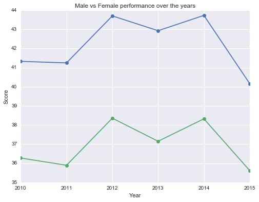

```python
f, ax = plt.subplots(figsize=(8,6))
plt.plot(ind, year_gender_avg['mscore'].values, marker='o')
plt.plot(ind, year_gender_avg['fscore'].values, marker='o')
plt.title('Male vs Female performance over the years')
plt.xlabel('Year')
plt.ylabel('Score')
plt.xticks(ind, year_gender_avg.index);
```

From the plot above we can see that(as well as the table before) we can see that boys on average perform better than girls, country-wide year-after-year. The reasons for this could be various and this mainly because of the pressures on girls in rural areas. We can make the same plot for girls in Kampala and some of the other urban areas to investigate this.

It is also important to note that the shapes of the plots for boys and girls have very similar shapes and the distance between them is almost the same throughout. This suggests that within each gender the score varies by the same amount each year. Probably reacting to the difficualty of the exams or strictness of the examiners. Whichever factor it is, it affects the sexes equally.

```python
kla_gender_avg = ple[ple['district']=='KAMPALA'].groupby('year')[['mscore','fscore']].mean()
kla_gender_avg
```

| year | mscore | fscore |
| --- | --- | --- |
| 2010 | 63.856977 | 58.488233 |
| 2011 | 64.121104 | 59.493312 |
| 2012 | 66.290300 | 60.896014 |
| 2013 | 63.281305 | 57.686106 |
| 2014 | 63.905150 | 59.800240 |
| 2015 | 61.430815 | 57.435561 |

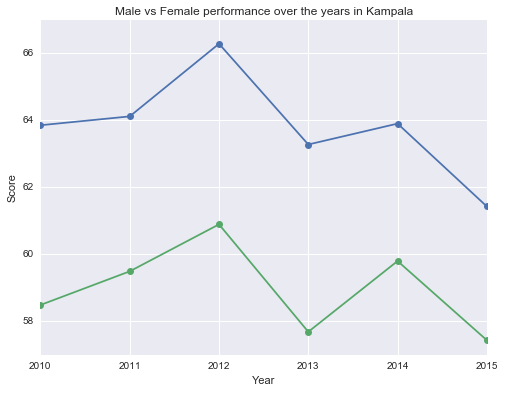

```python
f, ax = plt.subplots(figsize=(8,6))
plt.plot(ind, kla_gender_avg['mscore'].values, marker='o')
plt.plot(ind, kla_gender_avg['fscore'].values, marker ='o')
plt.title('Male vs Female performance over the years in Kampala')
plt.xlabel('Year')
plt.ylabel('Score')
plt.xticks(ind, kla_gender_avg.index);
```

The graphs don't differ greatly from the ones we had before. They also share a similar shape with each other. We can not that as would be expected the scores in Kampala are better than the average country scores. The difference beween boys and girls is a bit smaller in Kampala than the results fromthe analysis of the national results. This may suggest that the issues that cause girls to perform worse than boys around the country are not uniwue to those areas, at least some of them.

Of course this is still open to further analysis possibly combined with other datasets. We have also only used the PLE dataset of the three that we had. We can dive deeper and search for trends and insights using the UCE and UACE results as well as check to see if our findings here show up in those results as well.